# HW3

# Network communities

## Yahoo Music Network

For this assignment, you have to load [the part of Yahoo Music Network](https://drive.google.com/file/d/0Bwd5a7NScgMtNElfOFdSbE1UYnM/view). Archive contains network in GML format and corresponding list of artists.

```r
# open the file with graph
yahoo_music_path <- file.path('C:', 'Users', 'Mikhail', 'Desktop', 'SNA3', 'music2K.gml')
yahoo_music <- read.graph(yahoo_music_path, format='gml')

# open the file with names
yahoo_artists_path <- file.path('C:', 'Users', 'Mikhail', 'Desktop', 'SNA3', 'artists.txt')
yahoo_artists <- readLines(yahoo_artists_path)
```

Edges in this network appear if enough number of users have given ratings to both music bands. Note, that edges are weighted with similarity of the ratings.

### 1. Preprocessing

This network needs to be preprocessed. Do the steps, described on seminar, to make it look properly. How many vertices and edges were deleted?

First, we delete isolated nodes and after that simplify the structure of the graph.

```r
# remove unused names
vertices_i_to_delete <- V(yahoo_music)[degree(yahoo_music) == 0]
yahoo_artists <- yahoo_artists[-vertices_i_to_delete]

# remove disconnected vertices
before_vcount <- vcount(yahoo_music)
yahoo_music <- delete.vertices(yahoo_music, vertices_i_to_delete)
after_vcount <- vcount(yahoo_music)
paste('Number of deleted vertices:', before_vcount - after_vcount)
```

```
## [1] "Number of deleted vertices: 4"
```

```r
# remove multiple edges and loops
before_ecount <- ecount(yahoo_music)
yahoo_music <- simplify(yahoo_music)
after_ecount <- ecount(yahoo_music)
paste('Number of deleted edges:', before_ecount - after_ecount)
```

```
## [1] "Number of deleted edges: 0"
```

```r
# add labels to yahoo graph
V(yahoo_music)$label <- yahoo_artists
```

### 2. Clustering

Define clusters for this networks using one of the algorithms described on lectures and seminars:

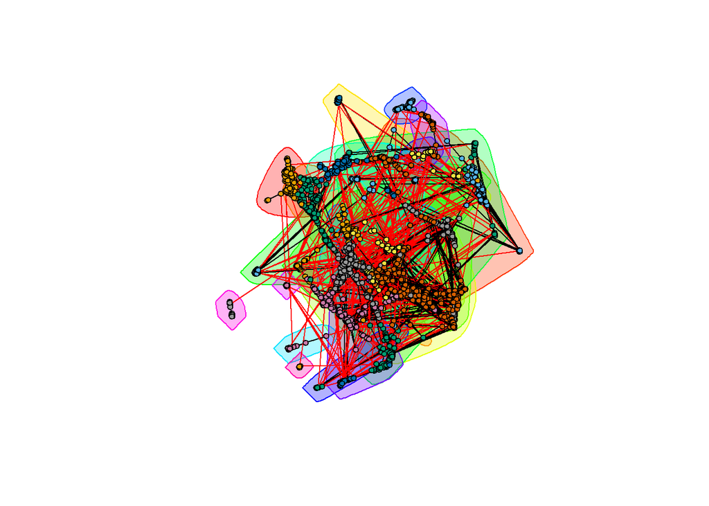

```r
# To do this task fastgreedy.community will be used:
yahoo_communities <- fastgreedy.community(yahoo_music)
plot(yahoo_communities, yahoo_music, vertex.label=NA, vertex.size=4)
```

Compute density of obtained clusters:

```r
yahoo_communities_list <- vector('list', length(yahoo_communities))
yahoo_communities_densities <- vector('list', length(yahoo_communities))

for (i in 1:length(yahoo_communities)) {
  yahoo_communities_list[[i]] <- induced.subgraph(yahoo_music, yahoo_communities$membership == i)
  yahoo_communities_densities[[i]] <- graph.density(yahoo_communities_list[[i]])
}

unlist(yahoo_communities_densities)
```

```
##  [1] 0.05004296 0.06020067 0.03955257 0.08078431 0.10740203 0.01904649
##  [7] 0.03927859 0.04745063 0.08783322 0.06127583 0.05211249 0.23076923
## [13] 0.06841046 0.10101010 0.17028986 0.03753688 0.22857143 0.09813665
## [19] 0.33986928 0.13547237 0.12765957 0.13446970 0.53846154 0.25362319
## [25] 0.52380952 0.57692308 0.64285714
```

Compute the ratio of inner clusters connections to outer ones:

```r
total_edges <- ecount(yahoo_music)
yahoo_communities_inout <- vector('list', length(yahoo_communities))
for (i in 1:length(yahoo_communities)) {
  curr_comm_edges <- ecount(yahoo_communities_list[[i]])
  yahoo_communities_inout[[i]] <- curr_comm_edges / (total_edges - curr_comm_edges)
}

unlist(yahoo_communities_inout)
```

```
##  [1] 0.036208236 0.039276808 0.070992612 0.015689261 0.022699387
##  [6] 0.168185004 0.090076835 0.050740624 0.040087350 0.053896001
## [11] 0.062290903 0.012296949 0.026161896 0.023013194 0.007098626
## [16] 0.098517298 0.007250755 0.036852745 0.007859734 0.011529126
## [21] 0.021133231 0.010762468 0.006338666 0.010609276 0.001652396
## [26] 0.006794504 0.002706767
```

### 3. Visualization & interpretation

Visulize five of the most dense clusters. Use names of artists as node labels on the graph.

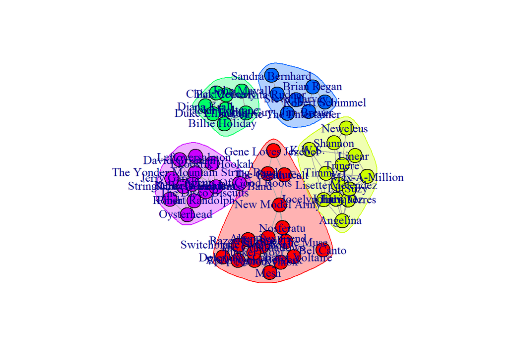

```r
# find indexes of top5 dense clusters
top5_dense_clusters_i <- which(yahoo_communities_densities >= sort(
  unlist(yahoo_communities_densities), decreasing = TRUE)[5])

# find nodes in these clusters
top5_dense_vertices <- V(yahoo_music)[yahoo_communities$membership %in% top5_dense_clusters_i]

# create a graph from them
top5_dense_graph <- induced.subgraph(yahoo_music, top5_dense_vertices)

SCC <- clusters(top5_dense_graph, mode="strong")
V(top5_dense_graph)$color <- rainbow(SCC$no)[SCC$membership]
plot(top5_dense_graph, mark.groups = split(1:vcount(top5_dense_graph), SCC$membership))
```

**(Extra task)** Try to interpret (using Wikipedia or other resources) obtained clusters.

Red (Gene Loves Jezebel, Xymox, …) - rock bands,

Green (Diana Krall, John Mayall, …) - jazz music,

Purple (Agents Of Good Roots, Phish, …) - rock (again),

Blue (Rita Rudner, Sandra Bernhard, …) - comedians,

Yellow (K.W.S, Newcleus, …) - electro music.